# R

Pai Jing-Yun

# Introduction to R

### Basic features in R

We tell R to make the assignment using an arrow “<-”. R also supports using “=” in most circumstances. However, “<-” is recommended as it makes clear that we are requesting an assignment, rather than stating a relation.

```r
a <- 3 ^ 5
b = 3 ^ 5
a
```

```
## [1] 243
```

```r
b
```

```
## [1] 243
```

If you don’t assign a value to a name of variable, then you will get the error message.

### Special values in R

Missing value, Not a Number, Infinity, π, and 10−3

```r
NA
```

```
## [1] NA
```

```r
NaN ### 0/0
```

```
## [1] NaN
```

```r
Inf ### 2/0
```

```
## [1] Inf
```

```r
-Inf ### -2/0
```

```
## [1] -Inf
```

```r
pi
```

```
## [1] 3.141593
```

```r
1e-3
```

```
## [1] 0.001
```

### Name an objuect

- Avoid the following words:
  - break; else; FALSE; F; TRUE; F; for; function; if; Inf; NA; NaN; next; repeat; return; while;
- Name a meaningful object by “.” or "_".
  - score1, score2
  - score.John, score.Jack

### More on calculation

Absolute value: |x|

```r
abs(-2)
```

```
## [1] 2
```

Exponential & logarithm: exp(x), log(x)

```r
exp(10); log(2); log2(2); log(10); log10(10)
```

```
## [1] 22026.47
```

```
## [1] 0.6931472
```

```
## [1] 1
```

```
## [1] 2.302585
```

```
## [1] 1
```

```r
log(10, base = 10); log10(10);log(10, base = exp(1)); log(10)
```

```
## [1] 1
```

```
## [1] 1
```

```
## [1] 2.302585
```

```
## [1] 2.302585
```

“ˆ” or "**" means the degree of the power

```r
2 ** 3; 2^3;2^0.5; sqrt(2)
```

```
## [1] 8
```

```
## [1] 8
```

```
## [1] 1.414214
```

```
## [1] 1.414214
```

Trigonometric function: sin(), cos(), tan(), asin(), acos(), atan()

### R is not just a calculator

There are a lot of functions you can use. Let’s see some related to Statistics.

```r
x <- 1:25
mean(x)
```

```
## [1] 13
```

```r
var(x)
```

```
## [1] 54.16667
```

```r
median(x)
```

```
## [1] 13
```

```r
quantile(x, c(0.1, 0.5, 0.7))
```

```
##  10%  50%  70%
##  3.4 13.0 17.8
```

We use c() to be a collection of needed values

```r
x <- c(1, 3, 5, 7, 9, 11)
y <- c(2, 4, 6, 8, 10, 12)
x
```

```
## [1]  1  3  5  7  9 11
```

```r
y
```

```
## [1]  2  4  6  8 10 12
```

Easy way to get the summary of a set

```r
summary(x)
```

```
##    Min. 1st Qu.  Median    Mean 3rd Qu.    Max.
##     1.0     3.5     6.0     6.0     8.5    11.0
```

### Figures of a set

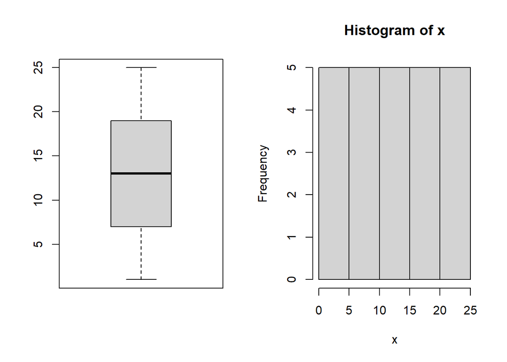

```r
x <- c(1:25, NA)
par(mfrow = c(1, 2))
boxplot(x)
hist(x)
```

# Introduction to vector

```r
vt1 <- c(2:4)
vt2 <- c(3:6)
vt2 <- c(vt2, vt1)
vt2
```

```
## [1] 3 4 5 6 2 3 4
```

```r
vt2 <- c(vt2, vt1)
vt2
```

```
##  [1] 3 4 5 6 2 3 4 2 3 4
```

### Some common functions to vectors

```r
length(vt1)
```

```
## [1] 3
```

```r
length(vt2)
```

```
## [1] 10
```

Extracting elements from vectors, use [ ] to select the locations in the vector. Note that the count is different from C and python.

```r
vt1[3]
```

```
## [1] 4
```

```r
vt2[c(3,5,7)]
```

```
## [1] 5 2 4
```

We can select all but the some elements of the vector as follows:

```r
vt1
```

```
## [1] 2 3 4
```

```r
vt1[-2]
```

```
## [1] 2 4
```

```r
vt2[-c(3:6)]
```

```
## [1] 3 4 4 2 3 4
```

```r
x <- c(3, 6, 9)
x * 3
```

```
## [1]  9 18 27
```

```r
x - 3
```

```
## [1] 0 3 6
```

```r
x ^ 3
```

```
## [1]  27 216 729
```

```r
y1 <- c(3, 2); y2 <- c(3, 2, 4);
x^y1
```

```
## [1]  27  36 729
```

```r
x^y2
```

```
## [1]   27   36 6561
```

When the vectors are different lengths, the shorter one is extended by recycling

```r
c(1, 1, 2, 2, 3, 3, 4, 4, 5, 5, 6, 6, 7, 7, 8, 8, 9, 9, 10, 10) %% 2:3
```

```
##  [1] 1 1 0 2 1 0 0 1 1 2 0 0 1 1 0 2 1 0 0 1
```

Recycling: rep(x, ntimes)

```r
c(1, 1, 2, 2, 3, 3, 4, 4, 5, 5, 6, 6, 7, 7, 8, 8, 9, 9, 10, 10) %% rep(2:3, 10)
```

```
##  [1] 1 1 0 2 1 0 0 1 1 2 0 0 1 1 0 2 1 0 0 1
```

Use “seq()” and “rep()” to construct a vector with similar patterns.

```r
rep(3, 12)
```

```
##  [1] 3 3 3 3 3 3 3 3 3 3 3 3
```

```r
rep(seq(2, 10, 2), 2)
```

```
##  [1]  2  4  6  8 10  2  4  6  8 10
```

```r
rep(c(1, 4), c(3, 2))
```

```
## [1] 1 1 1 4 4
```

```r
rep(seq(2, 10, 2), rep(3, 5))
```

```
##  [1]  2  2  2  4  4  4  6  6  6  8  8  8 10 10 10
```

```r
Xvector <- rep(NA, 6)
Xvector[3] <- 12
Xvector[c(4:6)] <- rep(1, 3)
Xvector
```

```
## [1] NA NA 12  1  1  1
```

How to delete NA?

```r
Xvector[-(1:2)]
```

```
## [1] 12  1  1  1
```

```r
Xvector <- Xvector[-(1:2)]
Xvector
```

```
## [1] 12  1  1  1
```

- When to use “c( )” and when to use a vector with known length?
  - c( ): Easy to add a value into the vector; need not know the length.
  - rep(NA, n): With known length and the position of elements.

Use “unique( )” to return the elements that appear at least one time. Use “table( )” to count the number of each element from the vector. Let b = {3, 3, 3, 3, 5, 5, 1, 2, 10, 10, 8}

```r
b <- c(3, 3, 3, 3, 5, 5, 1, 2, 10, 10, 8)
unique(b)
```

```
## [1]  3  5  1  2 10  8
```

```r
table(b)
```

```
## b
##  1  2  3  5  8 10
##  1  1  4  2  1  2
```

Set Operations

```r
B <- c(3, 1, 5, 4, 7); C <- c(23, 1, 44, 5, 3)
union(B, C)
```

```
## [1]  3  1  5  4  7 23 44
```

```r
intersect(B, C)
```

```
## [1] 3 1 5
```

```r
setdiff(B, C)
```

```
## [1] 4 7
```

```r
setequal(B, C)
```

```
## [1] FALSE
```

From small to large values, use “sort( )” or “order( )” to sort a vector or get the position of sorting of a vector.

```r
a <- c(3, 4, 2, 7, 10, 23, 8, 9, 11)
sort(a)
```

```
## [1]  2  3  4  7  8  9 10 11 23
```

```r
sort(a, decreasing = TRUE)
```

```
## [1] 23 11 10  9  8  7  4  3  2
```

Get the position (index) of sorting of a vector

```r
a <- c(3, 4, 2, 7, 10, 23, 8, 9, 11)
inc.order <- order(a)
dec.order <- order(a, decreasing = TRUE)
inc.order
```

```
## [1] 3 1 2 4 7 8 5 9 6
```

```r
a[inc.order]
```

```
## [1]  2  3  4  7  8  9 10 11 23
```

```r
dec.order
```

```
## [1] 6 9 5 8 7 4 2 1 3
```

```r
a[dec.order]
```

```
## [1] 23 11 10  9  8  7  4  3  2
```

### Change values in a vector

Let a = {3, 4, 2, 7, 10, 23, 8, 9, 11}. Change the 5th element to -3 and the 8th element to -1.

```r
a <- c(3, 4, 2, 7, 10, 23, 8, 9, 11)
a[5] <- -3
a[8] <- -1
a
```

```
## [1]  3  4  2  7 -3 23  8 -1 11
```

```r
vt1
```

```
## [1] 2 3 4
```

```r
vt1[-2]
```

```
## [1] 2 4
```

```r
vt2[-c(3:6)]
```

```
## [1] 3 4 4 2 3 4
```

### Character vectors

```r
"Hello World!!!"
```

```
## [1] "Hello World!!!"
```

```r
print("Hello R World!!!")
```

```
## [1] "Hello R World!!!"
```

```r
TEXT1 <- "Let's go to a game."
strsplit(TEXT1, " ")
```

```
## [[1]]
## [1] "Let's" "go"    "to"    "a"     "game."
```

```r
TEXT2 <- "Hurry! We are late!"
strsplit(TEXT2, "!")
```

```
## [[1]]
## [1] "Hurry"        " We are late"
```

```r
toupper(TEXT1)
```

```
## [1] "LET'S GO TO A GAME."
```

```r
tolower(TEXT2)
```

```
## [1] "hurry! we are late!"
```

```r
colors <- c("red", "yellow", "BLUE")
more.colors <- c(colors, "green", "cyan")
more.colors
```

```
## [1] "red"    "yellow" "BLUE"   "green"  "cyan"
```

```r
z <- c("red", "green", 12)
z
```

```
## [1] "red"   "green" "12"
```

### Basic operations for character vectors

-To take substrings, use “substr( )”

```r
colors <- c("red", "yellow", "blue")
substr(colors, 1, 3)
```

```
## [1] "red" "yel" "blu"
```

To search a string from a vector, use “grep()”, which is “Global Regular Expression Print”. It returns the locations of the desired patterns

```r
grep("y", more.colors)
```

```
## [1] 2 5
```

```r
grep("e", more.colors)
```

```
## [1] 1 2 4
```

```r
y.in.V <- grep("y", more.colors)
e.in.V <- grep("e", more.colors)
more.colors[y.in.V]
```

```
## [1] "yellow" "cyan"
```

```r
more.colors[e.in.V]
```

```
## [1] "red"    "yellow" "green"
```

```r
E.in.V <- grep("E", more.colors)
more.colors[E.in.V]
```

```
## [1] "BLUE"
```

-To building up strings, use “paste()”.

```r
paste(colors, "line") ## with space
```

```
## [1] "red line"    "yellow line" "blue line"
```

```r
paste(colors, "line", sep = "" ) ## no space
```

```
## [1] "redline"    "yellowline" "blueline"
```

```r
## use ";" to seperate strings
paste("I like", colors, collapse = "; ")
```

```
## [1] "I like red; I like yellow; I like blue"
```

factors

```r
colors <- c("red", "yellow", "blue")
f.c <- factor(colors)
f.c
```

```
## [1] red    yellow blue
## Levels: blue red yellow
```

```r
levels(f.c)
```

```
## [1] "blue"   "red"    "yellow"
```

```r
as.integer(f.c)
```

```
## [1] 2 3 1
```

### logical vector

TRUE and FALSE are reserved words denoting logical constants in the R, whereas T and F are global variables whose initial values set to these. Binary operators which allow the comparison of values in atomic vectors (relational operators).

```r
c(3 < 5, 3 > 5)
```

```
## [1]  TRUE FALSE
```

```r
c(3 <= 5, 3 >= 5)
```

```
## [1]  TRUE FALSE
```

```r
3 == 5
```

```
## [1] FALSE
```

```r
3 != 5
```

```
## [1] TRUE
```

```r
#Boolean operations
A <- c(T, T, F, T, F); B <- c(3, 1, 5, 4, 7)
A
```

```
## [1]  TRUE  TRUE FALSE  TRUE FALSE
```

```r
B[A]
```

```
## [1] 3 1 4
```

```r
!A
```

```
## [1] FALSE FALSE  TRUE FALSE  TRUE
```

```r
B[!A]
```

```
## [1] 5 7
```

```r
#How many TRUE (or FALSE) in the vector?
A <- c(T, T, F, T, F)
sum(A)
```

```
## [1] 3
```

```r
sum(!A)
```

```
## [1] 2
```

```r
#Compare the same location of elements individually
B <- c(3, 1, 5, 4, 7); C <- c(23, 1, 44, 5, 3)
B == C
```

```
## [1] FALSE  TRUE FALSE FALSE FALSE
```

```r
D <- c(2, 5 ,6, 10)
B == D
```

```
## [1] FALSE FALSE FALSE FALSE FALSE
```

### “is.” series

```r
is.null(c())
```

```
## [1] TRUE
```

```r
c(is.na(NA), is.na(2))
```

```
## [1]  TRUE FALSE
```

```r
x1 <- 1:5
x2 <- c(1:3, 2.2)
x3 <- colors
c(is.integer(x1), is.numeric(x1), is.double(x1))
```

```
## [1]  TRUE  TRUE FALSE
```

```r
c(is.integer(x2), is.numeric(x2), is.double(x2))
```

```
## [1] FALSE  TRUE  TRUE
```

```r
c(is.character(x3), is.numeric(x3))
```

```
## [1]  TRUE FALSE
```

```r
#Use “class( )” to identify the type of a vector
a <- c(3, 4, 2, 7, 10, 23, 8, 9, 11)
b <- c("red", "yellow", "blue")
c <- c(TRUE, FALSE)
d <- f.c
c(class(a), class(b), class(c), class(d))
```

```
## [1] "numeric"   "character" "logical"   "factor"
```

```r
c(class(2), class(2.0), class(as.integer(2)))
```

```
## [1] "numeric" "numeric" "integer"
```

# Matrix

### Construct a matrix

A matrix is a generalization containing multiple vectors.

```r
a <- 1:5; b <- 6:10;
c <- 11:15; d <- 16:20;
M1 <- rbind(a, b, c, d)
M1
```

```
##   [,1] [,2] [,3] [,4] [,5]
## a    1    2    3    4    5
## b    6    7    8    9   10
## c   11   12   13   14   15
## d   16   17   18   19   20
```

```r
M2 <- cbind(a, b, c, d)
M2
```

```
##      a  b  c  d
## [1,] 1  6 11 16
## [2,] 2  7 12 17
## [3,] 3  8 13 18
## [4,] 4  9 14 19
## [5,] 5 10 15 20
```

```r
dim(M1)
```

```
## [1] 4 5
```

```r
dim(M2)
```

```
## [1] 5 4
```

```r
X <- 1:20
matrix(X, nrow = 4, ncol = 5)
```

```
##      [,1] [,2] [,3] [,4] [,5]
## [1,]    1    5    9   13   17
## [2,]    2    6   10   14   18
## [3,]    3    7   11   15   19
## [4,]    4    8   12   16   20
```

```r
matrix(X, nrow = 5, ncol = 4)
```

```
##      [,1] [,2] [,3] [,4]
## [1,]    1    6   11   16
## [2,]    2    7   12   17
## [3,]    3    8   13   18
## [4,]    4    9   14   19
## [5,]    5   10   15   20
```

```r
matrix(X, nrow = 4, ncol = 5, byrow = TRUE)
```

```
##      [,1] [,2] [,3] [,4] [,5]
## [1,]    1    2    3    4    5
## [2,]    6    7    8    9   10
## [3,]   11   12   13   14   15
## [4,]   16   17   18   19   20
```

```r
matrix(X, nrow = 5, ncol = 4, byrow = TRUE)
```

```
##      [,1] [,2] [,3] [,4]
## [1,]    1    2    3    4
## [2,]    5    6    7    8
## [3,]    9   10   11   12
## [4,]   13   14   15   16
## [5,]   17   18   19   20
```

### Features for a matrix

```r
M1
```

```
##   [,1] [,2] [,3] [,4] [,5]
## a    1    2    3    4    5
## b    6    7    8    9   10
## c   11   12   13   14   15
## d   16   17   18   19   20
```

```r
dim(M1)
```

```
## [1] 4 5
```

```r
colnames(M1); rownames(M1);
```

[output not shown]

```
## [1] "a" "b" "c" "d"
```

```r
colnames(M1) <- c("V1", "V2", "V3", "V4", "V5")
dimnames(M1)
```

```
## [[1]]
## [1] "a" "b" "c" "d"
##
## [[2]]
## [1] "V1" "V2" "V3" "V4" "V5"
```

```r
dimnames(M2)
```

```
## [[1]]
## NULL
##
## [[2]]
## [1] "a" "b" "c" "d"
```

We still use “[ ]” to extract elements from a matrix, but using a “,” to identify the locations of row and column seperately.

```r
M1[2, 4];M1[c(2, 4), 3]; M1[c(2, 4), c(3, 5)];M1[, 4];
```

```
## [1] 9
```

```
##  b  d
##  8 18
```

```
##   V3 V5
## b  8 10
## d 18 20
```

```
##  a  b  c  d
##  4  9 14 19
```

```r
M1[c(2, 4), ]; M1[, c(3, 5)]
```

```
##   V1 V2 V3 V4 V5
## b  6  7  8  9 10
## d 16 17 18 19 20
```

```
##   V3 V5
## a  3  5
## b  8 10
## c 13 15
## d 18 20
```

```r
#Extract elements by names
M1[c("b", "c"), ]
```

```
##   V1 V2 V3 V4 V5
## b  6  7  8  9 10
## c 11 12 13 14 15
```

```r
#The names of columns are V1, V2, V3, V4, and V5. Take the rows of b and c and the columns of V2 and V5.
```

[output not shown]